# Methods 2 – Portfolio Assignment 3

- *Type:* Group assignment
- *Due:* 8 May 2022, 23:59
- *Instructions:* All problems are exercises from *Regression and Other Stories*. Please edit this file here and add your solutions.

```r
pacman::p_load(rstan, rstanarm, tidyverse, ggplot2, car, dplyr, bayesplot, brms)
```

## 1. Exercise 10.5

*Regression modeling and prediction:* The folder `KidIQ` contains a subset of the children and mother data discussed earlier in the chapter. You have access to children’s test scores at age 3, mother’s education, and the mother’s age at the time she gave birth for a sample of 400 children.

### Loading data

```r
child_df = read_csv("child_iq.csv") %>%
  mutate( #Renaming some things so that it's easier to deal with
    child_score = ppvt,
    mom_education = educ_cat,
    mom_age=momage,
  ) %>%
  select(c(child_score, mom_education, mom_age))
head(child_df)
```

| child_score | mom_education | mom_age |
| --- | --- | --- |
| 120 | 2 | 21 |
| 89 | 1 | 17 |
| 78 | 2 | 19 |
| 42 | 1 | 20 |
| 115 | 4 | 26 |
| 97 | 1 | 20 |

```r
str(child_df)
```

```
## tibble [400 x 3] (S3: tbl_df/tbl/data.frame)
##  $ child_score  : num [1:400] 120 89 78 42 115 97 94 68 103 94 ...
##  $ mom_education: num [1:400] 2 1 2 1 4 1 1 2 3 3 ...
##  $ mom_age      : num [1:400] 21 17 19 20 26 20 20 24 19 24 ...
```

```r
#Function to get the confidence interval
#Because of the nature of simulations the output of the functions will not necessarily match the reported confident intervals. Since the posterior distribution is rarely normal, we use bootstrapping to obtain an estimate of the confidence intervals instead of using the standard deviation for calculating it.

confidence_interval <- function(v) {
  q = quantile(v, probs = c(0.05, 0.95))
  c(q[["5%"]], q[["95%"]])
}
```

*(a) Fit a regression of child test scores on mother’s age, display the data and fitted model, check assumptions, and interpret the slope coefficient. Based on this analysis, when do you recommend mothers should give birth? What are you assuming in making this recommendation?*

```r
par(mfrow = c(1,2))
#Fitting model
model = stan_glm(child_score ~ mom_age, data=child_df, refresh= 0)
summary(model)
```

```
##
## Model Info:
##  function:     stan_glm
##  family:       gaussian [identity]
##  formula:      child_score ~ mom_age
##  algorithm:    sampling
##  sample:       4000 (posterior sample size)
##  priors:       see help('prior_summary')
##  observations: 400
##  predictors:   2
##
## Estimates:
##               mean   sd   10%   50%   90%
## (Intercept) 67.9    8.8 56.6  67.7  79.2
## mom_age      0.8    0.4  0.3   0.8   1.3
## sigma       20.4    0.7 19.4  20.4  21.3
##
## Fit Diagnostics:
##            mean   sd   10%   50%   90%
## mean_PPD 86.9    1.5 85.1  86.9  88.8
##
## The mean_ppd is the sample average posterior predictive distribution of the outcome variable (for details see help('summary.stanreg')).
##
## MCMC diagnostics
##               mcse Rhat n_eff
## (Intercept)   0.1  1.0  4132
## mom_age       0.0  1.0  4156
## sigma         0.0  1.0  4050
## mean_PPD      0.0  1.0  4124
## log-posterior 0.0  1.0  1756
##
## For each parameter, mcse is Monte Carlo standard error, n_eff is a crude measure of effective sample size, and Rhat is the potential scale reduction factor on split chains (at convergence Rhat=1).
```

```r
model$coef
```

```
## (Intercept)     mom_age
##  67.7446097   0.8405028
```

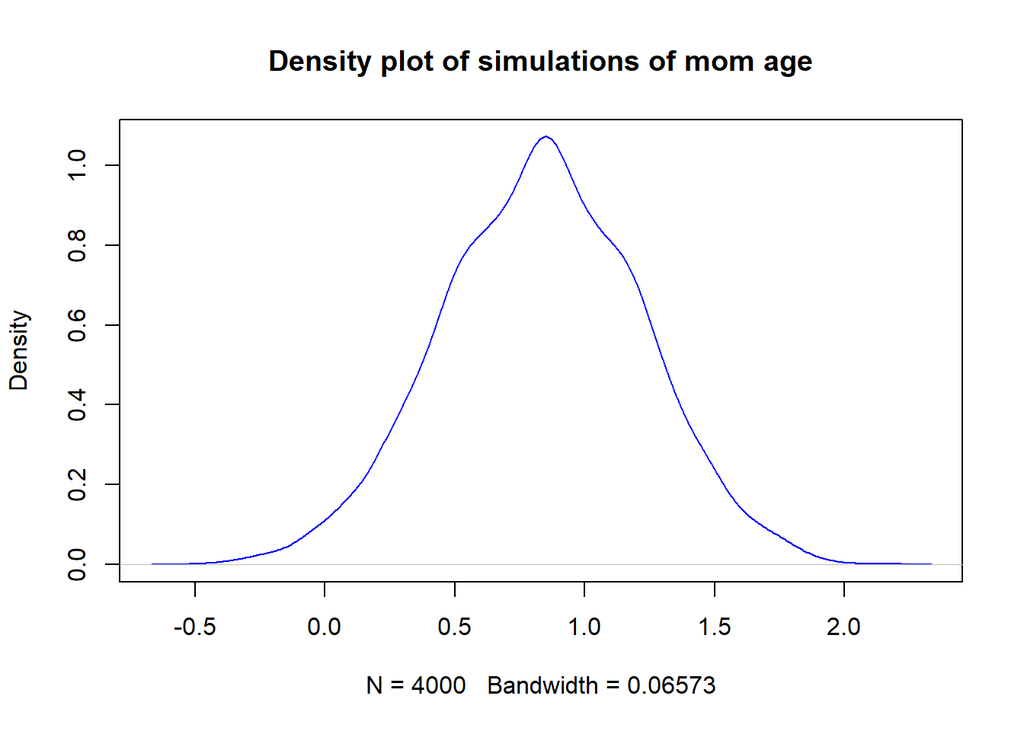

```r
#Obtaining the results of the simulations and turning them into a tibble
simulations = as.matrix(model) %>% data.frame() %>% tibble()
density(simulations$mom_age) %>% plot(main = "Density plot of simulations of mom age", col="blue")
```

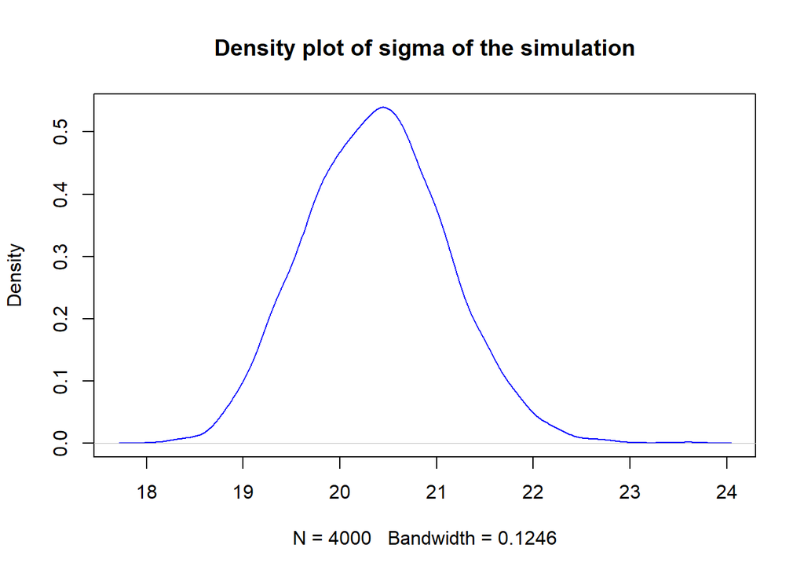

```r
density(simulations$sigma) %>% plot(main = "Density plot of sigma of the simulation", col="blue")
```

```r
str(simulations)
```

```
## tibble [4,000 x 3] (S3: tbl_df/tbl/data.frame)
##  $ X.Intercept.: num [1:4000] 63.2 72 62 77.8 81.7 ...
##  $ mom_age     : num [1:4000] 1.076 0.679 1.128 0.418 0.281 ...
##  $ sigma       : num [1:4000] 20.3 21 21 20.6 20.5 ...
```

```r
#getting the confidence intervals of the posterior distribution
confidence_interval(simulations$X.Intercept.)
```

```
## [1] 53.55951 82.45269
```

```r
confidence_interval(simulations$mom_age)
```

```
## [1] 0.2033548 1.4618342
```

```r
confidence_interval(simulations$sigma)
```

```
## [1] 19.21426 21.58869
```

Assuming that the only thing predicting and influencing the child’s IQ is the mother’s age, this tendency would indicate that women should have children later in life. So the older the mother the higher the child’s IQ. Moreover, this recommendation is based solely on the assumption that the ultimate consideration for when to give birth is to maximize child IQ.

It has to be noted that the estimate of sigma is quite large, suggesting that the model leaves a lot of unexplained variance in the data.

The effect size of 0.84 is relatively small as well. Even if there is a relationship between mom’s age and child IQ, it is not particularly strong.

### Checking assumptions

```r
par(mfrow = c(2,2))

#Checking normality of residuals
hist(model$residuals, main ="Residuals of the model")
shapiro.test(model$residuals)
```

```
##
##  Shapiro-Wilk normality test
##
## data:  model$residuals
## W = 0.97531, p-value = 2.551e-06
```

```r
qqnorm(model$residuals, pch = 1, frame = FALSE)
qqline(model$residuals, col = "steelblue", lwd = 2)

#checking for homoscedasticity
bartlett.test(child_score ~ mom_age, data=child_df)
```

```
##
##  Bartlett test of homogeneity of variances
##
## data:  child_score by mom_age
## Bartlett's K-squared = 14.674, df = 12, p-value = 0.2598
```

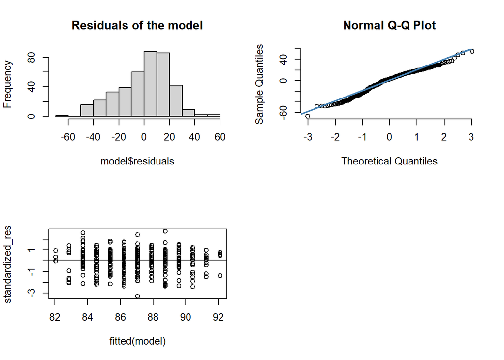

```r
#Residual vs fitted plot
res=model$residuals
standardized_res <- (res - mean(res))/sd(res)

plot(fitted(model), standardized_res)
abline(0,0)
```

We can see that the residuals of the model are not normally distributed, but the variances are homogeneous. By visual inspection, we can see that the assumption of linearity is not broken either. For the highest and lowest values of x, homogeneity of the variance is mildly violated. However, this might be because of the sparsity of the data, but does not pose a problem.

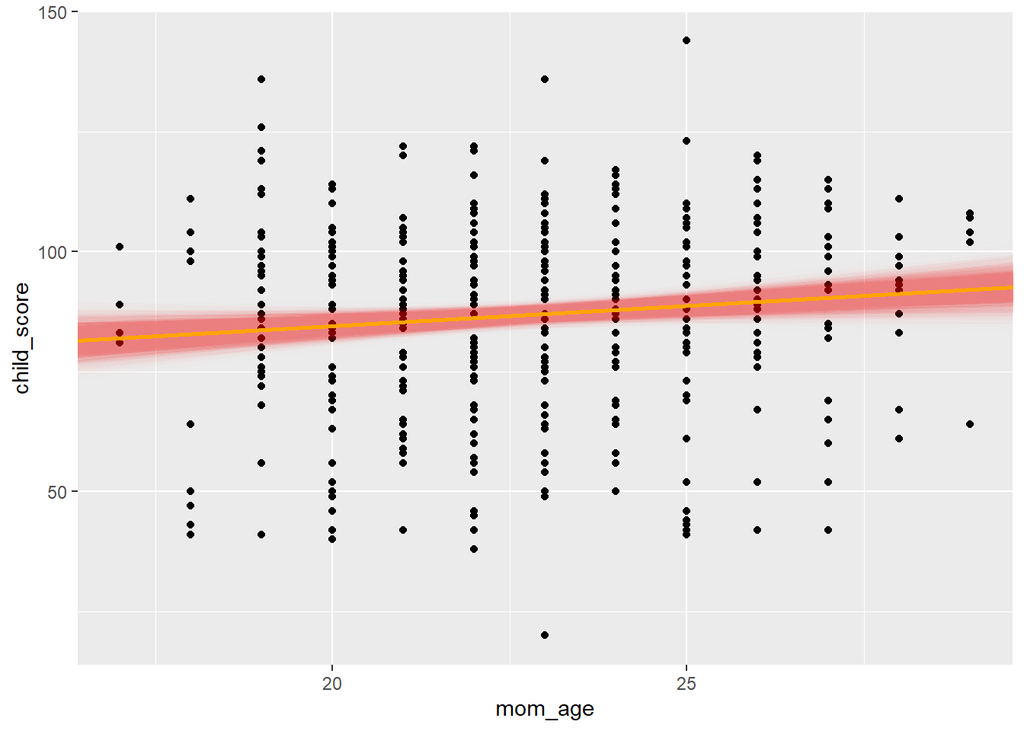

```r
#plotting the model
intercept = model$coefficients[["(Intercept)"]]
slope.mom_age = model$coefficients[["mom_age"]]
child_df %>%
  ggplot(aes(x = mom_age, y = child_score)) +
  geom_point() +
  geom_abline(
    data=simulations,
    aes(
      intercept = X.Intercept.,
      slope = mom_age
    ),
    alpha=0.002,
    color="red"
  ) +
  geom_abline(
    intercept = intercept,
    slope=slope.mom_age,
    color="orange",
    size=1
  )
```

All posterior simulations are plotted, with the orange line representing the mean of the posterior intercept and slope.

Upon visual inspection it becomes even more clear how weak of a relationship there is between mom’s age and a child’s IQ score. There is a lot of noise around the regression line.

*(b) Repeat this for a regression that further includes mother’s education, interpreting both slope coefficients in this model. Have your conclusions about the timing of birth changed?*

```r
par(mfrow = c(2,2))

#Factorize mom_education. Divide mom_education into high school or not (for next exercise)
child_df <- mutate(child_df, mom_hs = if_else(mom_education<2,"0","1"))
child_df <- child_df %>% mutate(mom_education = as.factor(mom_education))

#Making a model
model_2 = stan_glm(child_score ~ mom_education + mom_age, data=child_df, refresh=0)
summary(model_2)
```

```
##
## Model Info:
##  function:     stan_glm
##  family:       gaussian [identity]
##  formula:      child_score ~ mom_education + mom_age
##  algorithm:    sampling
##  sample:       4000 (posterior sample size)
##  priors:       see help('prior_summary')
##  observations: 400
##  predictors:   5
##
## Estimates:
##                  mean   sd   10%   50%   90%
## (Intercept)    72.2    8.7 61.0  72.4  83.4
## mom_education2 10.0    2.7  6.7  10.0  13.3
## mom_education3  8.9    3.2  4.8   8.9  13.0
## mom_education4 17.7    4.8 11.5  17.7  23.9
## mom_age         0.3    0.4 -0.2   0.3   0.8
## sigma          19.9    0.7 19.0  19.9  20.9
##
## Fit Diagnostics:
##            mean   sd   10%   50%   90%
## mean_PPD 86.9    1.4 85.1  86.9  88.8
##
## The mean_ppd is the sample average posterior predictive distribution of the outcome variable (for details see help('summary.stanreg')).
##
## MCMC diagnostics
##                mcse Rhat n_eff
## (Intercept)    0.1  1.0  3981
## mom_education2 0.1  1.0  2282
## mom_education3 0.1  1.0  2311
## mom_education4 0.1  1.0  2420
## mom_age        0.0  1.0  3225
## sigma          0.0  1.0  4431
## mean_PPD       0.0  1.0  4299
## log-posterior  0.0  1.0  1629
##
## For each parameter, mcse is Monte Carlo standard error, n_eff is a crude measure of effective sample size, and Rhat is the potential scale reduction factor on split chains (at convergence Rhat=1).
```

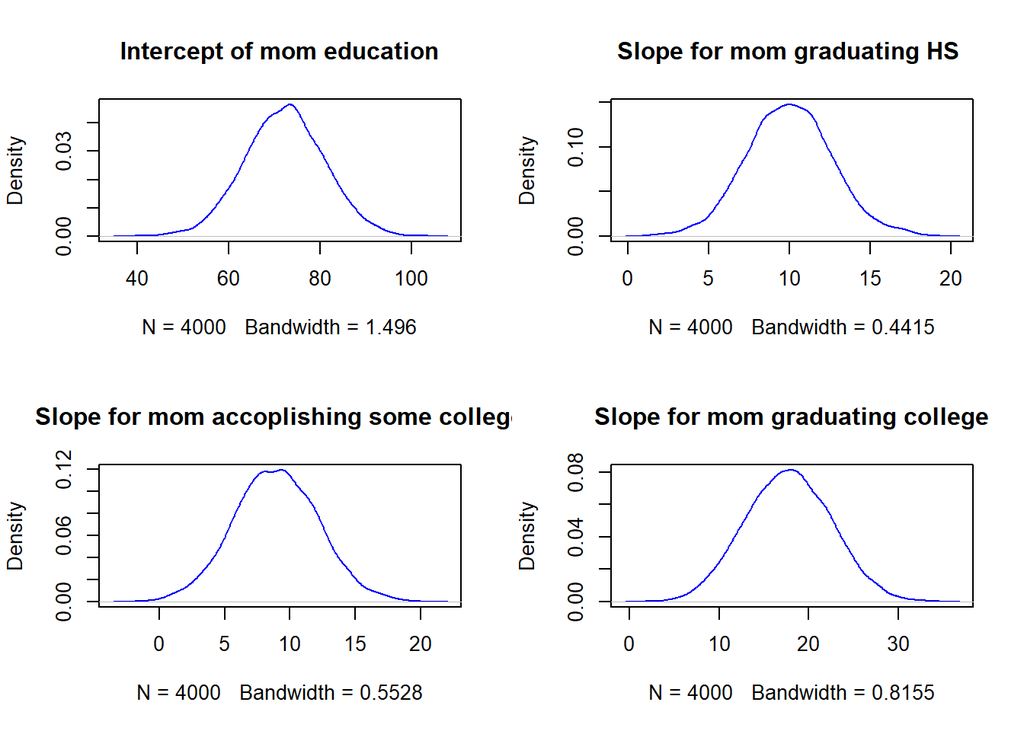

```r
simulations_2 = as.matrix(model_2) %>%
  data.frame() %>%
  tibble()

par(mfrow = c(2,2))
density(simulations_2$X.Intercept.) %>%
  plot(main = "Intercept of mom education", col="blue")


density(simulations_2$mom_education2) %>%
  plot(main = "Slope for mom graduating HS ", col="blue")

density(simulations_2$mom_education3) %>%
  plot(main = "Slope for mom accoplishing some college", col="blue")

density(simulations_2$mom_education4) %>%
  plot(main = "Slope for mom graduating college", col="blue")
```

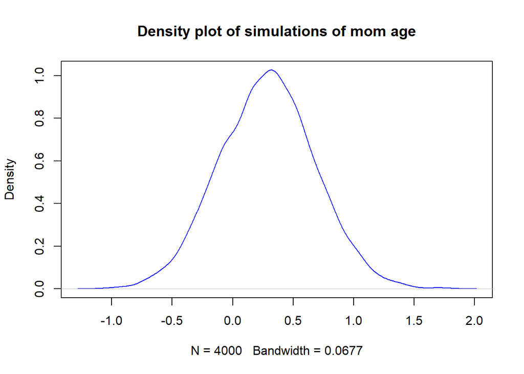

```r
density(simulations_2$mom_age) %>%
  plot(main = "Density plot of simulations of mom age", col="blue")
```

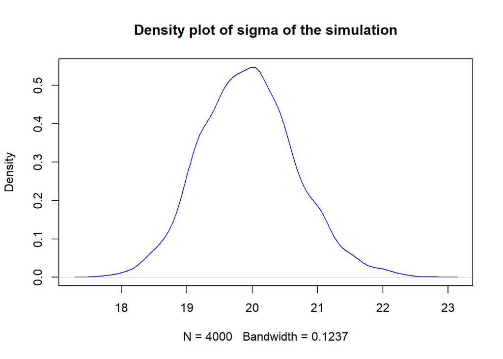

```r
density(simulations_2$sigma) %>%
  plot(main = "Density plot of sigma of the simulation", col="blue")
```

```r
confidence_interval(simulations_2$mom_age)
```

```
## [1] -0.3634550  0.9365906
```

Based on this model, our recommendation would be to complete as many educational programs as possible before having children. Therefore, our recommendations are no longer based on the age of the mother, but on her educational level. For maximizing a child’s IQ, our recommendation is that women should have children after completing an entire college degree.

*(c) Now create an indicator variable reflecting whether the mother has completed high school or not. Consider interactions between high school completion and mother’s age. Also create a plot that shows the separate regression lines for each high school completion status group.*

```r
#Adding a new column


child_df <- child_df %>% mutate(mom_hs = as.factor(mom_hs))
```

```r
par(mfrow = c(2,2))

#Creating model
model_3 = stan_glm(child_score ~ mom_age * mom_hs, data=child_df, refresh=0)
simulations_3 = as.matrix(model_3) %>% data.frame() %>% tibble()
summary(model_3)
```

```
##
## Model Info:
##  function:     stan_glm
##  family:       gaussian [identity]
##  formula:      child_score ~ mom_age * mom_hs
##  algorithm:    sampling
##  sample:       4000 (posterior sample size)
##  priors:       see help('prior_summary')
##  observations: 400
##  predictors:   4
##
## Estimates:
##                   mean   sd    10%   50%   90%
## (Intercept)     103.5   17.3  80.9 103.6 125.7
## mom_age          -1.2    0.8  -2.2  -1.2  -0.1
## mom_hs1         -36.2   19.7 -61.4 -36.5 -11.4
## mom_age:mom_hs1   2.1    0.9   1.0   2.1   3.3
## sigma            19.9    0.7  19.0  19.9  20.8
##
## Fit Diagnostics:
##            mean   sd   10%   50%   90%
## mean_PPD 87.0    1.4 85.2  86.9  88.8
##
## The mean_ppd is the sample average posterior predictive distribution of the outcome variable (for details see help('summary.stanreg')).
##
## MCMC diagnostics
##                 mcse Rhat n_eff
## (Intercept)     0.5  1.0  1420
## mom_age         0.0  1.0  1398
## mom_hs1         0.5  1.0  1327
## mom_age:mom_hs1 0.0  1.0  1294
## sigma           0.0  1.0  2077
## mean_PPD        0.0  1.0  3035
## log-posterior   0.0  1.0  1459
##
## For each parameter, mcse is Monte Carlo standard error, n_eff is a crude measure of effective sample size, and Rhat is the potential scale reduction factor on split chains (at convergence Rhat=1).
```

```r
confidence_interval(simulations_3$mom_age)
```

```
## [1] -2.4314285  0.1763457
```

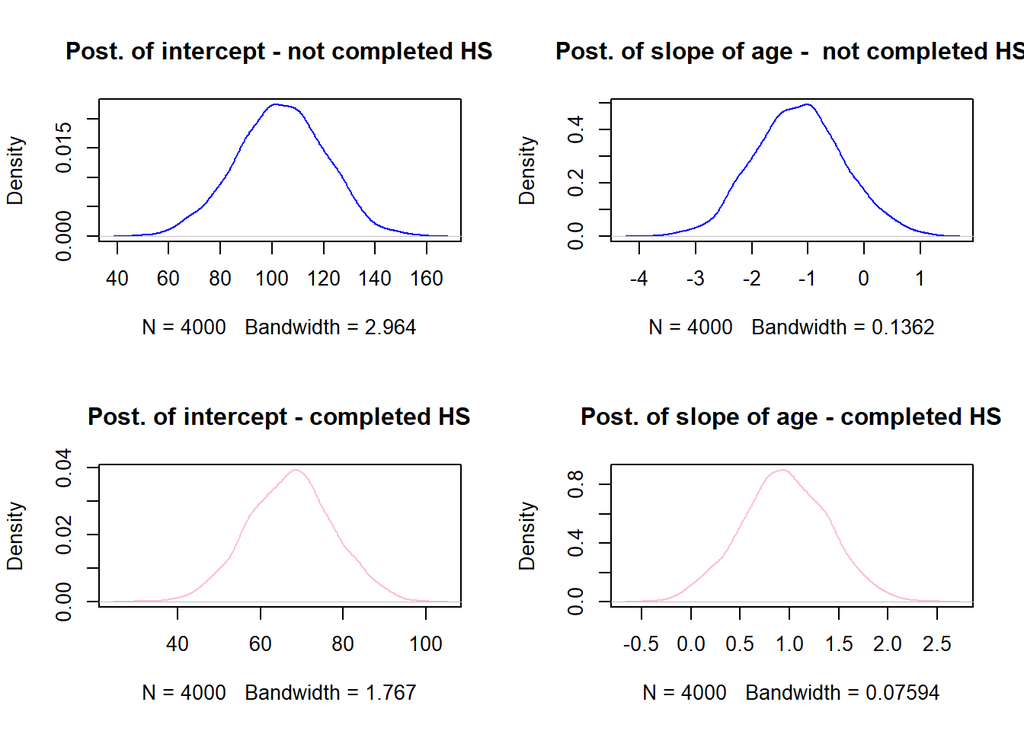

```r
#Plotting the posterior distributions of the estimates
par(mfrow = c(2,2))
density(
  simulations_3$X.Intercept.) %>%
  plot(col="blue",
  main = "Post. of intercept - not completed HS")


density(
  simulations_3$mom_age) %>%
  plot(col="blue",
  main = "Post. of slope of age -  not completed HS")


density(
  simulations_3$mom_hs1 + simulations_3$X.Intercept.) %>%
  plot(col="pink",
  main = "Post. of intercept - completed HS")

density(
  simulations_3$mom_age.mom_hs1 + simulations_3$mom_age) %>%
  plot(col="pink",
  main = "Post. of slope of age - completed HS")
```

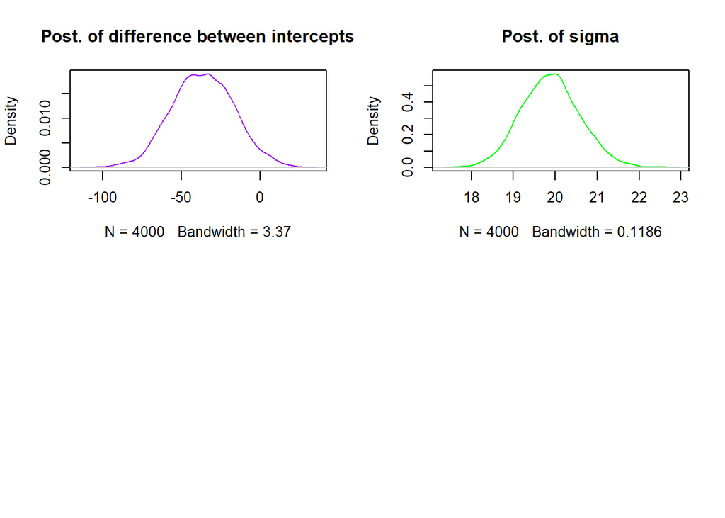

```r
density(simulations_3$mom_hs1) %>% plot(main="Post. of difference between intercepts", col = "purple")

density(simulations_3$sigma) %>% plot(main = "Post. of sigma", col="green")
```

### Plotting mcmc_intervals

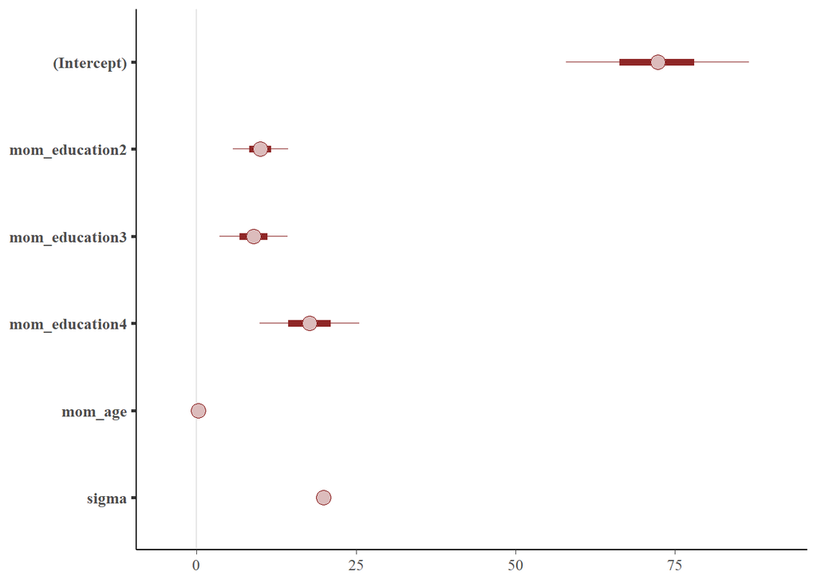

```r
color_scheme_set("red")
mcmc_intervals(model_2, pars = c("(Intercept)", "mom_education2","mom_education3","mom_education4","mom_age","sigma"))
```

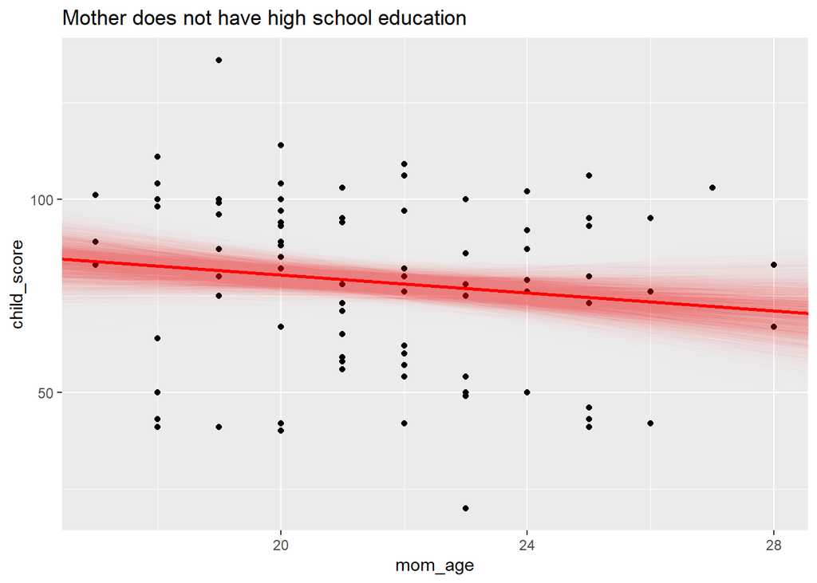

```r
#Plotting the model
intercept = model_3$coefficients[["(Intercept)"]]
slope.mom_age = model_3$coefficients[["mom_age"]]
slope.mom_high_school = model_3$coefficients[["mom_hs1"]]
slope.interaction = model_3$coefficients[["mom_age:mom_hs1"]]

mom_no_hs_df = child_df %>% filter(mom_hs == 0)
mom_hs_df = child_df %>% filter(mom_hs == 1)

mom_no_hs_df %>% ggplot(aes(x = mom_age, y = child_score)) +
  geom_point() +
  geom_abline(
    data=simulations_3,
    aes(
      intercept = X.Intercept.,
      slope = mom_age
    ),
    alpha=0.002,
    color="red"
  ) +
  geom_abline(intercept = intercept, slope = slope.mom_age, color="red", size=1) +
  ggtitle("Mother does not have high school education")
```

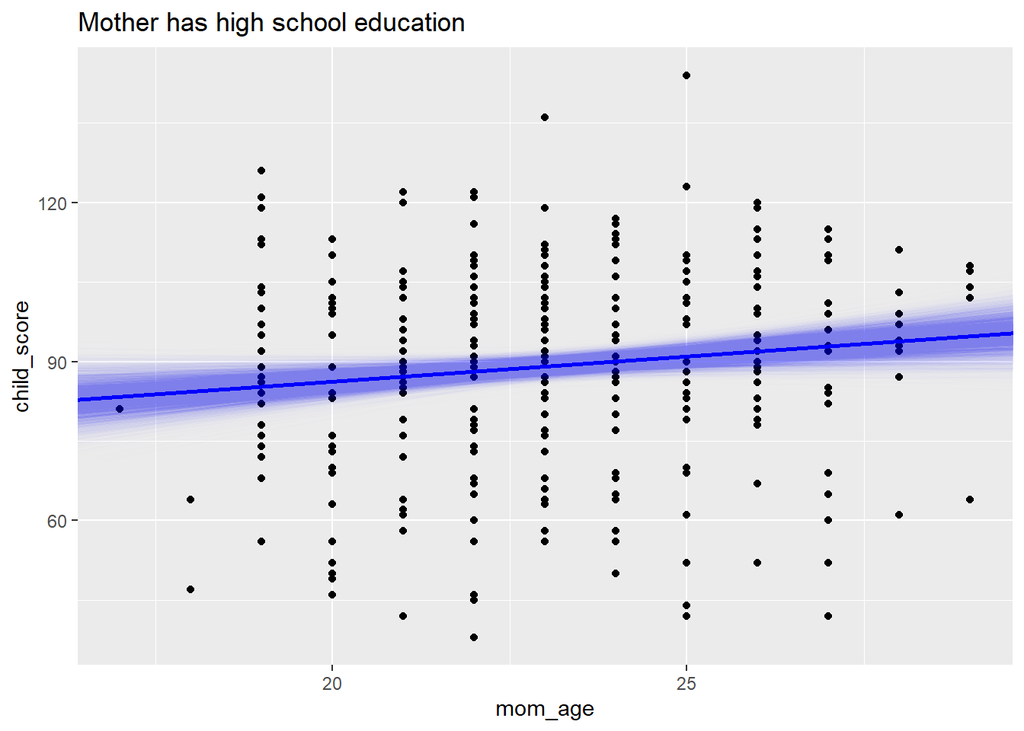

```r
mom_hs_df %>% ggplot(aes(x = mom_age, y=child_score)) +
  geom_point() +
  geom_abline(
    data=simulations_3,
    aes(
      intercept = X.Intercept. + mom_hs1,
      slope = mom_age.mom_hs1 + mom_age
    ),
    alpha=0.002,
    color="blue"
  ) +
  geom_abline(
    intercept = intercept + slope.mom_high_school,
    slope = slope.mom_age + slope.interaction,
    color = "blue",
    size=1
  ) +
  ggtitle("Mother has high school education")
```

```r
confidence_interval(simulations_3$mom_hs1)
```

```
## [1] -68.062390  -3.910288
```

The mean of the posterior slope of moms completing high school is -35.6 (SD = 19.6), meaning that the baseline of child IQ decreases when moms complete high school. However, the magnitude of the decrease is of great uncertainty (CI: [-67.48 -3.31]).

The mean of the posterior slope of the interaction effect is 2.1 (SD = 0.9), showing that there is an antagonistic interaction between the age of the mother, and whether they have completed high school. As moms get older and complete a high school degree, child IQ increases.

Thus it seems advisable for educated women to have children later on in their lives, while uneducated women should aim for giving birth earlier.

*(d) Finally, fit a regression of child test scores on mother’s age and education level for the first 200 children and use this model to predict test scores for the next 200. Graphically display comparisons of the predicted and actual scores for the final 200 children.*

### Dividing the data

```r
train_data = child_df %>% slice_head(n=200)
test_data = child_df %>% slice_tail(n=200)
```

```r
model_4 = stan_glm(child_score ~ mom_age * mom_hs, data=train_data, refresh=0)

predictive_distribution = posterior_predict(model_4, newdata = test_data, draws=100)
```

### Plotting the observed and the posterior predict by high school completion

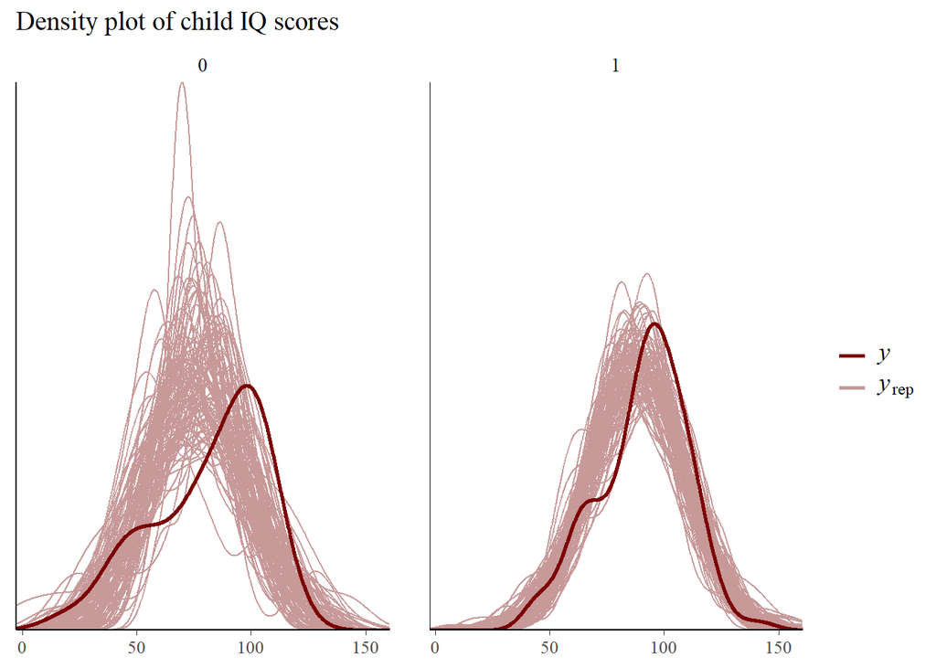

```r
ppc_dens_overlay_grouped(test_data$child_score, predictive_distribution, trim = FALSE, size = 0.5, alpha = 1, group = test_data$mom_hs) + labs(title = "Density plot of child IQ scores")
```

It seems that the model generalizes better for educated women (1), which is seen by the uncertainty shown in the plot for uneducated women(0). This can be due to the fact that the dataset contains more data from women who completed high school.

## 2. Exercise 10.6

*Regression models with interactions:* The folder `Beauty` contains data (use file `beauty.csv`) from Hamermesh and Parker (2005) on student evaluations of instructors’ beauty and teaching quality for several courses at the University of Texas. The teaching evaluations were conducted at the end of the semester, and the beauty judgments were made later, by six students who had not attended the classes and were not aware of the course evaluations.

```r
df_bea <- read_csv("beauty.csv")
df_bea$female <- as.factor(df_bea$female)
df_bea$minority <- as.factor(df_bea$minority)
```

*(a) Run a regression using beauty (the variable `beauty`) to predict course evaluations (`eval`), adjusting for various other predictors. Graph the data and fitted model, and explain the meaning of each of the coefficients along with the residual standard deviation. Plot the residuals versus fitted values.*

```r
model_bea <- stan_glm(eval ~ beauty + age + female, data = df_bea, refresh=0)
summary(model_bea)
```

```
##
## Model Info:
##  function:     stan_glm
##  family:       gaussian [identity]
##  formula:      eval ~ beauty + age + female
##  algorithm:    sampling
##  sample:       4000 (posterior sample size)
##  priors:       see help('prior_summary')
##  observations: 463
##  predictors:   4
##
## Estimates:
##               mean   sd   10%   50%   90%
## (Intercept)  4.2    0.1  4.0   4.2   4.4
## beauty       0.1    0.0  0.1   0.1   0.2
## age          0.0    0.0  0.0   0.0   0.0
## female1     -0.2    0.1 -0.3  -0.2  -0.1
## sigma        0.5    0.0  0.5   0.5   0.6
##
## Fit Diagnostics:
##            mean   sd   10%   50%   90%
## mean_PPD 4.0    0.0  4.0   4.0   4.0
##
## The mean_ppd is the sample average posterior predictive distribution of the outcome variable (for details see help('summary.stanreg')).
##
## MCMC diagnostics
##               mcse Rhat n_eff
## (Intercept)   0.0  1.0  4409
## beauty        0.0  1.0  4589
## age           0.0  1.0  4544
## female1       0.0  1.0  5066
## sigma         0.0  1.0  4552
## mean_PPD      0.0  1.0  4069
## log-posterior 0.0  1.0  1608
##
## For each parameter, mcse is Monte Carlo standard error, n_eff is a crude measure of effective sample size, and Rhat is the potential scale reduction factor on split chains (at convergence Rhat=1).
```

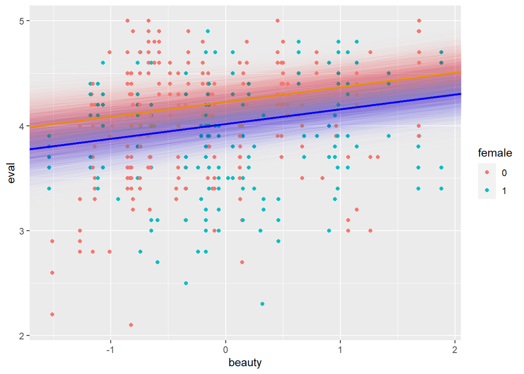

```r
simulations_bea = as.matrix(model_bea) %>% data.frame() %>% tibble()
df_bea %>%
  ggplot(aes(x=beauty, y=eval, color=female))+
  geom_point()+
  geom_abline(
    data = simulations_bea,
    aes(intercept=X.Intercept.,
        slope=beauty),
    alpha=0.002,
    color="red"
  ) +
  geom_abline(
    intercept = model_bea$coefficients[["(Intercept)"]],
    slope=model_bea$coefficients[["beauty"]],
    color="orange",
    size=1
  )+
  geom_abline(
    data = simulations_bea,
    aes(intercept=X.Intercept.+female1,
        slope=beauty),
    alpha=0.002,
    color="blue"
  ) +
  geom_abline(
    intercept = model_bea$coefficients[["(Intercept)"]]+model_bea$coefficients[["female1"]],
    slope=model_bea$coefficients[["beauty"]],
    color="blue",
    size=1
  )+
  scale_fill_brewer(palette = "RdYlGn")
```

### Plotting the model

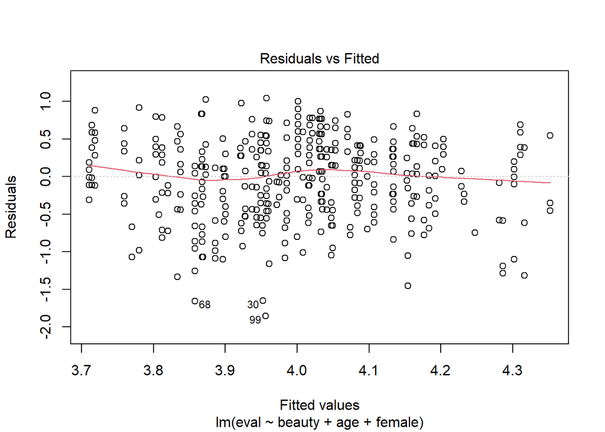

```r
plot(lm(eval~beauty+age+female, data = df_bea), 1)
```

```r
confidence_interval(simulations_bea$X.Intercept.)
```

```
## [1] 3.993656 4.455328
```

```r
confidence_interval(simulations_bea$X.Intercept.+simulations_bea$female1)
```

```
## [1] 3.802266 4.231135
```

```r
confidence_interval(simulations_bea$age)
```

```
## [1] -0.007058800  0.001962206
```

```r
confidence_interval(simulations_bea$beauty)
```

```
## [1] 0.08472062 0.19558438
```

```r
confidence_interval(simulations_bea$sigma)
```

```
## [1] 0.5102968 0.5685332
```

*(b) Fit some other models, including beauty and also other predictors. Consider at least one model with interactions. For each model, explain the meaning of each of its estimated coefficients.*

```r
model_bea3 <- stan_glm(eval ~ beauty * female, data= df_bea, refresh=0)
simulations_bea3 = as.matrix(model_bea3) %>% data.frame() %>% tibble()
summary(model_bea3)
```

```
##
## Model Info:
##  function:     stan_glm
##  family:       gaussian [identity]
##  formula:      eval ~ beauty * female
##  algorithm:    sampling
##  sample:       4000 (posterior sample size)
##  priors:       see help('prior_summary')
##  observations: 463
##  predictors:   4
##
## Estimates:
##                  mean   sd   10%   50%   90%
## (Intercept)     4.1    0.0  4.1   4.1   4.1
## beauty          0.2    0.0  0.1   0.2   0.3
## female1        -0.2    0.1 -0.3  -0.2  -0.1
## beauty:female1 -0.1    0.1 -0.2  -0.1   0.0
## sigma           0.5    0.0  0.5   0.5   0.6
##
## Fit Diagnostics:
##            mean   sd   10%   50%   90%
## mean_PPD 4.0    0.0  4.0   4.0   4.0
##
## The mean_ppd is the sample average posterior predictive distribution of the outcome variable (for details see help('summary.stanreg')).
##
## MCMC diagnostics
##                mcse Rhat n_eff
## (Intercept)    0.0  1.0  3527
## beauty         0.0  1.0  2651
## female1        0.0  1.0  4138
## beauty:female1 0.0  1.0  2779
## sigma          0.0  1.0  3325
## mean_PPD       0.0  1.0  3694
## log-posterior  0.0  1.0  1712
##
## For each parameter, mcse is Monte Carlo standard error, n_eff is a crude measure of effective sample size, and Rhat is the potential scale reduction factor on split chains (at convergence Rhat=1).
```

```r
confidence_interval(simulations_bea3$beauty)
```

```
## [1] 0.1271363 0.2678938
```

```r
confidence_interval(simulations_bea3$female1)
```

```
## [1] -0.2862532 -0.1220888
```

```r
confidence_interval(simulations_bea3$beauty.female1)
```

```
## [1] -0.212840726 -0.005306427
```

```r
model_bea4 <- stan_glm(eval ~ beauty * minority, data= df_bea, refresh=0)
simulations_bea4 = as.matrix(model_bea4) %>% data.frame() %>% tibble()
summary(model_bea4)
```

```
##
## Model Info:
##  function:     stan_glm
##  family:       gaussian [identity]
##  formula:      eval ~ beauty * minority
##  algorithm:    sampling
##  sample:       4000 (posterior sample size)
##  priors:       see help('prior_summary')
##  observations: 463
##  predictors:   4
##
## Estimates:
##                    mean   sd   10%   50%   90%
## (Intercept)       4.0    0.0  4.0   4.0   4.1
## beauty            0.2    0.0  0.1   0.2   0.2
## minority1        -0.1    0.1 -0.2  -0.1   0.0
## beauty:minority1 -0.2    0.1 -0.4  -0.2  -0.1
## sigma             0.5    0.0  0.5   0.5   0.6
##
## Fit Diagnostics:
##            mean   sd   10%   50%   90%
## mean_PPD 4.0    0.0  4.0   4.0   4.0
##
## The mean_ppd is the sample average posterior predictive distribution of the outcome variable (for details see help('summary.stanreg')).
##
## MCMC diagnostics
##                  mcse Rhat n_eff
## (Intercept)      0.0  1.0  5591
## beauty           0.0  1.0  5012
## minority1        0.0  1.0  6167
## beauty:minority1 0.0  1.0  4675
## sigma            0.0  1.0  5531
## mean_PPD         0.0  1.0  4307
## log-posterior    0.0  1.0  1907
##
## For each parameter, mcse is Monte Carlo standard error, n_eff is a crude measure of effective sample size, and Rhat is the potential scale reduction factor on split chains (at convergence Rhat=1).
```

```r
confidence_interval(simulations_bea4$beauty)
```

```
## [1] 0.109747 0.221658
```

```r
confidence_interval(simulations_bea4$female1)
```

```
## [1] NA NA
```

```r
confidence_interval(simulations_bea4$beauty.female1)
```

```
## [1] NA NA
```

## 3. Exercise 10.7

*Predictive simulation for linear regression:* Take one of the models from the previous exercise.

*(a) Instructor A is a 50-year-old woman who is a native English speaker and has a beauty score of −1. Instructor B is a 60-year-old man who is a native English speaker and has a beauty score of −0.5. Simulate 1000 random draws of the course evaluation rating of these two instructors. In your simulation, use posterior_predict to account for the uncertainty in the regression parameters as well as predictive uncertainty.*

```r
set.seed(837363839)
newA <- data_frame(age=50, beauty=-1, female=as.factor(1), nonenglish=0)
```

```r
newB <- data_frame(age=60, beauty=-0.5, female=as.factor(0), nonenglish=0)
y_postpredA <- posterior_predict(model_bea3, newdata = newA,draws=1000 )
y_postpredB <- posterior_predict(model_bea3, newdata = newB,draws=1000 )
summary(y_postpredA)
```

```
##        1
##  Min.   :1.607
##  1st Qu.:3.451
##  Median :3.799
##  Mean   :3.799
##  3rd Qu.:4.159
##  Max.   :5.469
```

```r
summary(y_postpredB)
```

```
##        1
##  Min.   :2.239
##  1st Qu.:3.648
##  Median :4.006
##  Mean   :3.999
##  3rd Qu.:4.333
##  Max.   :5.868
```

```r
y_diff <- as.data.frame(y_postpredA-y_postpredB)
colnames(y_diff) <- "X"
```

### Plotting the posterior predictive distribution

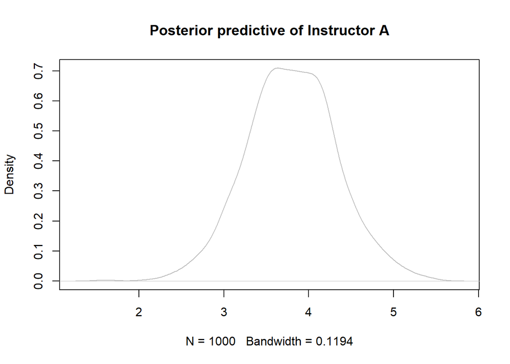

```r
density(y_postpredA) %>% plot(main="Posterior predictive of Instructor A", col = "grey")
```

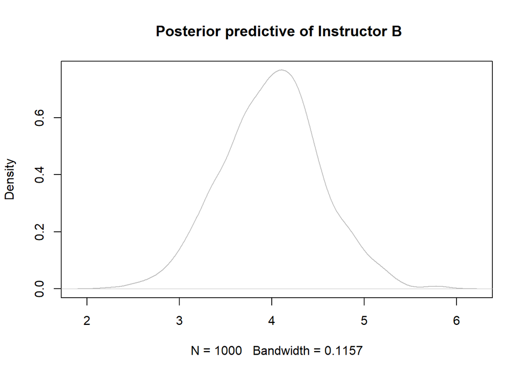

```r
density(y_postpredB) %>% plot(main=" Posterior predictive of Instructor B", col = "grey")
```

*(b) Make a histogram of the difference between the course evaluations for A and B. What is the probability that A will have a higher evaluation?*

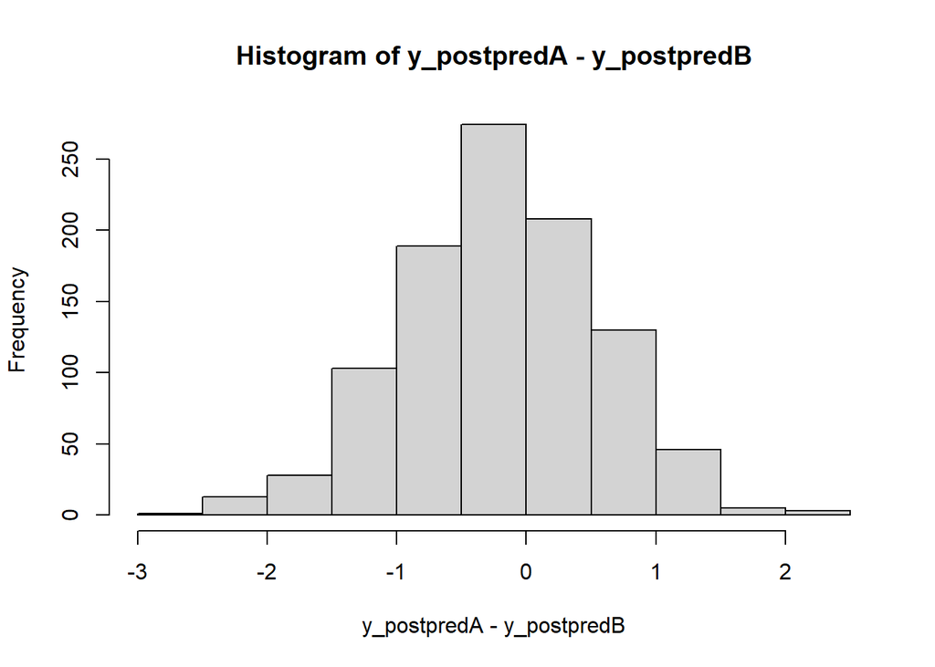

```r
hist(y_postpredA-y_postpredB)
```

```r
nrow(filter(y_diff,X>0))/1000
```

```
## [1] 0.392
```

The probability of A having a higher evaluation is around 40% depending on the simulation.